# Sparkify Project Workspace

This workspace contains a tiny subset (128MB) of the full dataset available (12GB). Feel free to use this workspace to build your project, or to explore a smaller subset with Spark before deploying your cluster on the cloud. Instructions for setting up your Spark cluster is included in the last lesson of the Extracurricular Spark Course content.

You can follow the steps below to guide your data analysis and model building portion of this project.

- artist: The name of the artist associated with the song being played.
- auth: The authentication status of the user, indicating whether the user is logged in or logged out.
- firstName: The first name of the user.
- gender: The gender of the user.
- itemInSession: The index of the item within the user's session.
- lastName: The last name of the user.
- length: The duration of the song being played.
- level: The subscription level of the user (free or paid).
- location: The location of the user.
- method: The HTTP method used for the request (GET or PUT).
- page: The specific page or action the user performed (e.g., "NextSong", "Thumbs Up", "Add to Playlist").
- registration: The timestamp when the user registered.
- sessionId: The ID of the user's session.
- song: The title of the song being played.
- status: The HTTP status code of the response.
- ts: The timestamp of the event.
- userAgent: The user agent string of the user's browser or client.
- userId: The unique identifier of the user.

**Objective** to define a model the predict the users' potential negative behaviour - cancel, downgrade - based on the users basic json info

```python
# import libraries
import pyspark
from pyspark.sql import SparkSession
from pyspark.sql.functions import col, udf, count, sum as sql_sum, avg, when
from pyspark.ml.feature import VectorAssembler
from pyspark.ml.classification import LogisticRegression
from pyspark.ml.evaluation import BinaryClassificationEvaluator
import matplotlib.pyplot as plt
import seaborn as sns
```

```python
# create a Spark session
spark = SparkSession.builder \
    .appName("Sparkify Data Analysis") \
    .getOrCreate()
```

# Load and Clean Dataset

In this workspace, the mini-dataset file is `mini_sparkify_event_data.json`. Load and clean the dataset, checking for invalid or missing data - for example, records without userids or sessionids.

```python
%ls ../../Datasets/UdacityCapstoneSpark/
```

```
ls: cannot access '../../Datasets/UdacityCapstoneSpark/': No such file or directory
```

```python
file_path = "./mini_sparkify_event_data.json"
# read the data via spark
sc = spark.read.json(file_path)
```

```python
sc.printSchema()
sc.show(5)
```

```
root
 |-- artist: string (nullable = true)
 |-- auth: string (nullable = true)
 |-- firstName: string (nullable = true)
 |-- gender: string (nullable = true)
 |-- itemInSession: long (nullable = true)
 |-- lastName: string (nullable = true)
 |-- length: double (nullable = true)
 |-- level: string (nullable = true)
 |-- location: string (nullable = true)
 |-- method: string (nullable = true)
 |-- page: string (nullable = true)
 |-- registration: long (nullable = true)
 |-- sessionId: long (nullable = true)
 |-- song: string (nullable = true)
 |-- status: long (nullable = true)
 |-- ts: long (nullable = true)
 |-- userAgent: string (nullable = true)
 |-- userId: string (nullable = true)

+----------------+---------+---------+------+-------------+--------+---------+-----+--------------------+------+--------+-------------+---------+--------------------+------+-------------+--------------------+------+
|          artist|     auth|firstName|gender|itemInSession|lastName|   length|level|            location|method|    page| registration|sessionId|                song|status|           ts|           userAgent|userId|
+----------------+---------+---------+------+-------------+--------+---------+-----+--------------------+------+--------+-------------+---------+--------------------+------+-------------+--------------------+------+
|  Martha Tilston|Logged In|    Colin|     M|           50| Freeman|277.89016| paid|     Bakersfield, CA|   PUT|NextSong|1538173362000|       29|           Rockpools|   200|1538352117000|Mozilla/5.0 (Wind...|    30|
|Five Iron Frenzy|Logged In|    Micah|     M|           79|    Long|236.09424| free|Boston-Cambridge-...|   PUT|NextSong|1538331630000|        8|              Canada|   200|1538352180000|"Mozilla/5.0 (Win...|     9|
|    Adam Lambert|Logged In|    Colin|     M|           51| Freeman| 282.8273| paid|     Bakersfield, CA|   PUT|NextSong|1538173362000|       29|   Time For Miracles|   200|1538352394000|Mozilla/5.0 (Wind...|    30|
|          Enigma|Logged In|    Micah|     M|           80|    Long|262.71302| free|Boston-Cambridge-...|   PUT|NextSong|1538331630000|        8|Knocking On Forbi...|   200|1538352416000|"Mozilla/5.0 (Win...|     9|
|       Daft Punk|Logged In|    Colin|     M|           52| Freeman|223.60771| paid|     Bakersfield, CA|   PUT|NextSong|1538173362000|       29|Harder Better Fas...|   200|1538352676000|Mozilla/5.0 (Wind...|    30|
+----------------+---------+---------+------+-------------+--------+---------+-----+--------------------+------+--------+-------------+---------+--------------------+------+-------------+--------------------+------+
only showing top 5 rows
```

```python
# Convert data types
columns_to_cast = {
    "userId": "Integer",
    "length": "Double"
}

for column, dtype in columns_to_cast.items():
    sc = sc.withColumn(column, sc[column].cast(dtype))
```

```python
sc.printSchema()
```

```
root
 |-- artist: string (nullable = true)
 |-- auth: string (nullable = true)
 |-- firstName: string (nullable = true)
 |-- gender: string (nullable = true)
 |-- itemInSession: long (nullable = true)
 |-- lastName: string (nullable = true)
 |-- length: double (nullable = true)
 |-- level: string (nullable = true)
 |-- location: string (nullable = true)
 |-- method: string (nullable = true)
 |-- page: string (nullable = true)
 |-- registration: long (nullable = true)
 |-- sessionId: long (nullable = true)
 |-- song: string (nullable = true)
 |-- status: long (nullable = true)
 |-- ts: long (nullable = true)
 |-- userAgent: string (nullable = true)
 |-- userId: integer (nullable = true)
```

```python
# convert it to pandas dataframe for a better overview
df = sc.toPandas()
```

```python
df.isnull().sum()
```

```
artist           58392
auth                 0
firstName         8346
gender            8346
itemInSession        0
lastName          8346
length           58392
level                0
location          8346
method               0
page                 0
registration      8346
sessionId            0
song             58392
status               0
ts                   0
userAgent         8346
userId            8346
dtype: int64
```

```python
df.length.isnull().sum()/df.shape[0]*100
```

```
20.381151832460734
```

> There are 20% of missing data in length, try to imputate the missing data with respect to length

```python
# compute the mean length for each userID
mean_length = sc.groupBy('userId').agg(avg('length').alias('mean_length'))

# join the mean lengths back to the original DataFrame
sc_length = sc.join(mean_length, on='userId', how='left')

# fill null values
sc_filled = sc_length.withColumn(
    'length_filled',when(sc_length['length'].isNull(), sc_length['mean_length']).otherwise(sc_length['length'])
)
# drop columns and rename the length_filled to length
sc_filled = sc_filled.drop('length','mean_length').withColumnRenamed('length_filled', 'length')
```

```python
sc_filled.toPandas().isnull().sum()
```

```
userId            8346
artist           58392
auth                 0
firstName         8346
gender            8346
itemInSession        0
lastName          8346
level                0
location          8346
method               0
page                 0
registration      8346
sessionId            0
song             58392
status               0
ts                   0
userAgent         8346
length            8346
dtype: int64
```

> From the above columns and the number of null values in each, the parameters that may determine the user behaviour may cover: gender, itemInSession, level, location, method, page, sessionId, status, ts, and userId. Using these parameters can minimise the null value to be dropped and give the maximum parameters for the model training

```python
df = sc_filled.toPandas()
```

```python
df.page.unique()
```

```
array(['NextSong', 'Add to Playlist', 'Roll Advert', 'Thumbs Up',
       'Downgrade', 'Thumbs Down', 'Home', 'Logout', 'Help', 'Login',
       'Upgrade', 'Add Friend', 'About', 'Settings', 'Submit Upgrade',
       'Submit Downgrade', 'Error', 'Save Settings', 'Cancel',
       'Cancellation Confirmation', 'Register', 'Submit Registration'], dtype=object)
```

```python
df.describe()
```

|  | userId | itemInSession | registration | sessionId | status | ts | length |
| --- | --- | --- | --- | --- | --- | --- | --- |
| count | 278154.000000 | 286500.000000 | 2.781540e+05 | 286500.000000 | 286500.000000 | 2.865000e+05 | 278154.000000 |
| mean | 59682.022786 | 114.414213 | 1.535359e+12 | 1041.526555 | 210.054597 | 1.540957e+12 | 249.106413 |
| std | 109091.949999 | 129.767262 | 3.291322e+09 | 726.776263 | 31.505078 | 1.507544e+09 | 89.875595 |
| min | 2.000000 | 0.000000 | 1.521381e+12 | 1.000000 | 200.000000 | 1.538352e+12 | 0.783220 |
| 25% | 51.000000 | 27.000000 | 1.533522e+12 | 336.000000 | 200.000000 | 1.539697e+12 | 207.986490 |
| 50% | 98.000000 | 70.000000 | 1.536664e+12 | 1013.000000 | 200.000000 | 1.540932e+12 | 246.056378 |
| 75% | 100004.000000 | 156.250000 | 1.537672e+12 | 1675.000000 | 200.000000 | 1.542266e+12 | 265.743220 |
| max | 300025.000000 | 1321.000000 | 1.543247e+12 | 2474.000000 | 404.000000 | 1.543799e+12 | 3024.665670 |

```python
sc = sc_filled
```

# Exploratory Data Analysis

When you're working with the full dataset, perform EDA by loading a small subset of the data and doing basic manipulations within Spark. In this workspace, you are already provided a small subset of data you can explore.

### Define Churn

Once you've done some preliminary analysis, create a column `Churn` to use as the label for your model. I suggest using the `Cancellation Confirmation` events to define your churn, which happen for both paid and free users. As a bonus task, you can also look into the `Downgrade` events.

### Explore Data

Once you've defined churn, perform some exploratory data analysis to observe the behavior for users who stayed vs users who churned. You can start by exploring aggregates on these two groups of users, observing how much of a specific action they experienced per a certain time unit or number of songs played.

```python
sc.show(5)
```

```
+------+----------------+---------+---------+------+-------------+--------+-----+--------------------+------+--------+-------------+---------+--------------------+------+-------------+--------------------+---------+
|userId|          artist|     auth|firstName|gender|itemInSession|lastName|level|            location|method|    page| registration|sessionId|                song|status|           ts|           userAgent|   length|
+------+----------------+---------+---------+------+-------------+--------+-----+--------------------+------+--------+-------------+---------+--------------------+------+-------------+--------------------+---------+
|    30|  Martha Tilston|Logged In|    Colin|     M|           50| Freeman| paid|     Bakersfield, CA|   PUT|NextSong|1538173362000|       29|           Rockpools|   200|1538352117000|Mozilla/5.0 (Wind...|277.89016|
|     9|Five Iron Frenzy|Logged In|    Micah|     M|           79|    Long| free|Boston-Cambridge-...|   PUT|NextSong|1538331630000|        8|              Canada|   200|1538352180000|"Mozilla/5.0 (Win...|236.09424|
|    30|    Adam Lambert|Logged In|    Colin|     M|           51| Freeman| paid|     Bakersfield, CA|   PUT|NextSong|1538173362000|       29|   Time For Miracles|   200|1538352394000|Mozilla/5.0 (Wind...| 282.8273|
|     9|          Enigma|Logged In|    Micah|     M|           80|    Long| free|Boston-Cambridge-...|   PUT|NextSong|1538331630000|        8|Knocking On Forbi...|   200|1538352416000|"Mozilla/5.0 (Win...|262.71302|
|    30|       Daft Punk|Logged In|    Colin|     M|           52| Freeman| paid|     Bakersfield, CA|   PUT|NextSong|1538173362000|       29|Harder Better Fas...|   200|1538352676000|Mozilla/5.0 (Wind...|223.60771|
+------+----------------+---------+---------+------+-------------+--------+-----+--------------------+------+--------+-------------+---------+--------------------+------+-------------+--------------------+---------+
only showing top 5 rows
```

```python
# rename the column names
from pyspark.sql.types import StringType
to_lower_coln = udf(lambda x: x.lower(), StringType())
```

```python
for col in sc.columns:
    sc.withColumn(col, to_lower_coln(col))
```

```python
# select the relevant columns
coln_selected = ['gender', 'itemInSession', 'level', 'location', 'length', 'method', 'page', 'sessionId', 'status', 'ts', 'userId']
sc_sl = sc.select(coln_selected)
```

```python
# drop na and duplicated
sc_cl = sc_sl.dropna()
sc_cl = sc_cl.dropDuplicates()
```

```python
# add a column of churn
to_label_churn = udf(lambda x: 2 if x == 'Cancellation Confirmation' else 1 if x == 'Downgrade' else 0)
sc_cl = sc_cl.withColumn('churn', to_label_churn(sc_cl.page))
```

```python
# convert time
import datetime
get_year = udf(lambda x: datetime.datetime.fromtimestamp(x / 1000.0). year)
get_month = udf(lambda x: datetime.datetime.fromtimestamp(x / 1000.0). month)
get_day = udf(lambda x: datetime.datetime.fromtimestamp(x / 1000.0). day)
get_hour = udf(lambda x: datetime.datetime.fromtimestamp(x / 1000.0). hour)
```

```python
sc_cl = sc_cl.withColumn('year', get_year(sc_cl.ts))
sc_cl = sc_cl.withColumn('month', get_month(sc_cl.ts))
sc_cl = sc_cl.withColumn('day', get_day(sc_cl.ts))
sc_cl = sc_cl.withColumn('hour', get_hour(sc_cl.ts))
```

```python
sc_cl = sc_cl.drop('ts')
```

```python
# convert the data types
columns_to_cast = {
    'churn': 'Integer',
    'year': 'Integer',
    'month': 'Integer',
    'day': 'Integer',
    'hour': 'Integer'
}

for column, dtype in columns_to_cast.items():
    sc_cl = sc_cl.withColumn(column, sc_cl[column].cast(dtype))
```

```python
# select on the state as the location
to_extract_state = udf(lambda s: s.split(',')[1].strip() if ',' in s else s)
```

```python
sc_cl = sc_cl.withColumn('state', to_extract_state(sc_cl.location))
```

```python
from pyspark.sql.functions import split, explode
sc_cl2 = sc_cl.withColumn('states', split(sc_cl.state, "-"))
sc_cl2 = sc_cl2.withColumn('state', explode(sc_cl2.states))
sc_cl = sc_cl2.drop('states','location')
```

> Now the data is wrangled

```python
# convert the sc data to pandas dataframe to visualise for a basic analysis
df_cl = sc_cl.toPandas()
```

```python
df_pc = df_cl[df_cl.churn == 2]
df_pc.sample(5)
```

|  | gender | itemInSession | level | length | method | page | sessionId | status | userId | churn | year | month | day | hour | state |
| --- | --- | --- | --- | --- | --- | --- | --- | --- | --- | --- | --- | --- | --- | --- | --- |
| 178990 | F | 29 | free | 248.427657 | GET | Cancellation Confirmation | 843 | 200 | 143 | 2 | 2018 | 10 | 15 | 7 | VA |
| 165763 | M | 7 | free | 255.720438 | GET | Cancellation Confirmation | 267 | 200 | 200011 | 2 | 2018 | 11 | 2 | 1 | MO |
| 161483 | M | 36 | free | 234.569640 | GET | Cancellation Confirmation | 42 | 200 | 100024 | 2 | 2018 | 10 | 4 | 23 | NJ |
| 200164 | F | 306 | paid | 250.405380 | GET | Cancellation Confirmation | 1519 | 200 | 28 | 2 | 2018 | 11 | 6 | 0 | OH |
| 83529 | M | 33 | free | 236.530829 | GET | Cancellation Confirmation | 270 | 200 | 200015 | 2 | 2018 | 11 | 9 | 7 | CA |

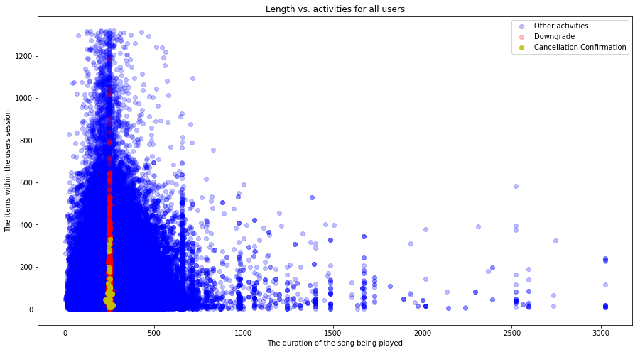

```python
# for all users
plt.figure(figsize=(15,8))
plt.scatter(x='length', y='itemInSession', data=df_cl[df_cl.churn == 0], c='b', alpha=0.25)
plt.scatter(x='length', y='itemInSession', data=df_cl[df_cl.churn == 1], c='r', alpha=0.25)
plt.scatter(x='length', y='itemInSession', data=df_cl[df_cl.churn == 2], c='y', alpha=0.85)
plt.xlabel('The duration of the song being played')
plt.ylabel('The items within the user''s session')
plt.legend(['Other activities','Downgrade','Cancellation Confirmation'])
plt.title('Length vs. activities for all users')
plt.show()
```

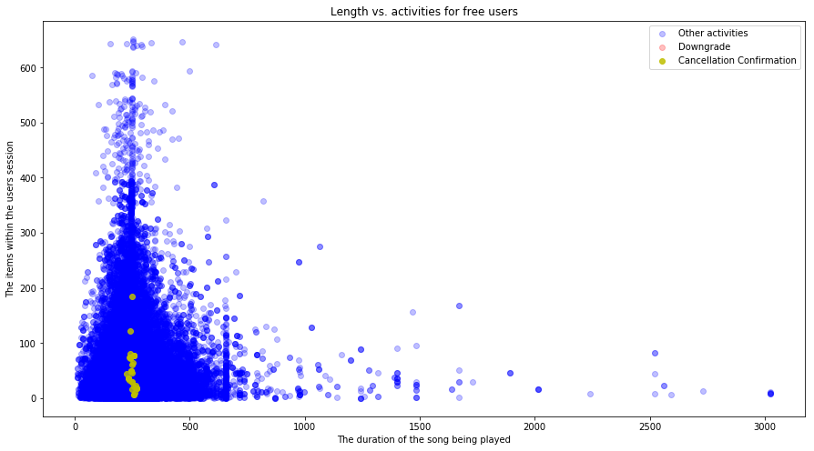

```python
# for free users
df_fr = df_cl[df_cl.level == 'free']
plt.figure(figsize=(15,8))
plt.scatter(x='length', y='itemInSession', data=df_fr[df_fr.churn == 0], c='b', alpha=0.25)
plt.scatter(x='length', y='itemInSession', data=df_fr[df_fr.churn == 1], c='r', alpha=0.25)
plt.scatter(x='length', y='itemInSession', data=df_fr[df_fr.churn == 2], c='y', alpha=0.85)
plt.xlabel('The duration of the song being played')
plt.ylabel('The items within the user''s session')
plt.legend(['Other activities','Downgrade','Cancellation Confirmation'])
plt.title('Length vs. activities for free users')
plt.show()
```

[figure not shown]

```python
# for paid users
df_pd = df_cl[df_cl.level == 'paid']
plt.figure(figsize=(15,8))
plt.scatter(x='length', y='itemInSession', data=df_pd[df_pd.churn == 0], c='b', alpha=0.25)
plt.scatter(x='length', y='itemInSession', data=df_pd[df_pd.churn == 1], c='r', alpha=0.25)
plt.scatter(x='length', y='itemInSession', data=df_pd[df_pd.churn == 2], c='y', alpha=0.85)
plt.xlabel('The duration of the song being played')
plt.ylabel('The items within the user''s session')
plt.legend(['Other activities','Downgrade','Cancellation Confirmation'])
plt.title('Length vs. activities for free users')
plt.show()
```

# Feature Engineering

Once you've familiarized yourself with the data, build out the features you find promising to train your model on. To work with the full dataset, you can follow the following steps.

- Write a script to extract the necessary features from the smaller subset of data
- Ensure that your script is scalable, using the best practices discussed in Lesson 3
- Try your script on the full data set, debugging your script if necessary

If you are working in the classroom workspace, you can just extract features based on the small subset of data contained here. Be sure to transfer over this work to the larger dataset when you work on your Spark cluster.

```python
# indexing the strings
from pyspark.ml.feature import StringIndexer, OneHotEncoder
```

```python
# select the relevant columns
coln_selected = ['gender', 'itemInSession', 'level', 'length', 'churn']
sc_cl = sc_cl.select(coln_selected)
```

```python
for col in sc_cl.columns:
    if sc_cl.select(col).dtypes[0][1] == 'string':
        print(col,':',sc_cl.select(col).dtypes[0][1])
        indexer = StringIndexer(inputCol=col, outputCol=col + "_index")
        sc_cl = indexer.fit(sc_cl).transform(sc_cl)
        sc_cl = sc_cl.drop(col).withColumnRenamed(col + "_index", col)
```

```
gender : string
level : string
```

```python
sc_cl.show()
```

```
+-------------+------------------+-----+------+-----+
|itemInSession|            length|churn|gender|level|
+-------------+------------------+-----+------+-----+
|           32|         406.07302|    0|   1.0|  1.0|
|           62|         447.79057|    0|   0.0|  1.0|
|            0|         179.46077|    0|   0.0|  0.0|
|           23|         435.93098|    0|   0.0|  0.0|
|           66|         284.81261|    0|   1.0|  1.0|
|          224|249.51833484266677|    0|   1.0|  0.0|
|          224|249.51833484266677|    0|   1.0|  0.0|
|          224|249.51833484266677|    0|   1.0|  0.0|
|          101|         200.56771|    0|   0.0|  0.0|
|          263|         197.53751|    0|   1.0|  0.0|
|          263|         197.53751|    0|   1.0|  0.0|
|          263|         197.53751|    0|   1.0|  0.0|
|           28|          217.0771|    0|   1.0|  1.0|
|          102|         220.55138|    0|   0.0|  0.0|
|           27|         264.61995|    0|   1.0|  1.0|
|          204|         259.68281|    0|   1.0|  0.0|
|           33|         361.19465|    0|   1.0|  1.0|
|            5|250.55272908309448|    0|   0.0|  0.0|
|          333|247.88055082899103|    0|   1.0|  0.0|
|           60|         178.20689|    0|   0.0|  0.0|
+-------------+------------------+-----+------+-----+
only showing top 20 rows
```

# Split data

```python
from pyspark.ml import Pipeline
from pyspark.ml.classification import RandomForestClassifier
from pyspark.ml.evaluation import MulticlassClassificationEvaluator
from pyspark.ml.feature import StringIndexer, VectorAssembler
from pyspark.ml.tuning import CrossValidator, ParamGridBuilder
```

```python
# Calculate the number of instances for each class
class_counts = sc_cl.groupBy('churn').count().collect()
churn_counts = [class_counts[0][1],class_counts[1][1],class_counts[2][1]]
max_count = max(churn_counts)
min_count = min(churn_counts)
mid_count = [x for x in churn_counts if x not in [max_count, min_count]][0]

# Calculate weights
mid_ratio = 2*min_count/mid_count
max_ratio = 2*min_count/max_count

# select the data based on the churns
churn_0 = sc_cl.where(sc_cl.churn == 0).sample(withReplacement=False, fraction=max_ratio, seed=42)
churn_1 = sc_cl.where(sc_cl.churn == 1).sample(withReplacement=False, fraction=mid_ratio, seed=42)
churn_2 = sc_cl.where(sc_cl.churn == 2)
# merge the data
sc_cl = churn_0.union(churn_1.union(churn_2))
```

```python
# Split the data into training and testing sets
train_data, rest_data = sc_cl.randomSplit([0.7, 0.3], seed=42)
valid_data, test_data = rest_data.randomSplit([0.5, 0.5], seed=42)
```

# Modeling

Split the full dataset into train, test, and validation sets. Test out several of the machine learning methods you learned. Evaluate the accuracy of the various models, tuning parameters as necessary. Determine your winning model based on test accuracy and report results on the validation set. Since the churned users are a fairly small subset, I suggest using F1 score as the metric to optimize.

> Training data is time consuming. The models with different parameters are trained via written .py files and saved in the git folder

> The following modelling work only loads the pre-trained models for comparison

```python
import shutil
from pyspark.ml import PipelineModel
```

```python
# Initialize Spark session
spark = SparkSession.builder.appName('predicting').getOrCreate()
```

```python
%ls
```

```
cv_model/                       __pycache__/
mini_sparkify_event_data.json   Sparkify_bak.ipynb
model_cv_dt_2_features.zip      Sparkify.ipynb
model_cv_dt_maxDepth_10_15.zip  sparkify_model_DecisionTree.ipynb
model_cv_dt_maxDepth_15_20.zip  sparkify_model_GBT.ipynb
model_cv_dt.zip                 sparkify_model_randomForest.ipynb
model_cv_rf.zip                 Sparkify-zh.ipynb
```

```python
def model_evalulation(model_path):
    # Load the pre-trained Spark model
    shutil.unpack_archive(model_path, "./cv_model")
    model = PipelineModel.load('./cv_model')
    # predicting the data
    predictions = model.transform(test_data)
    # evaluate f1
    evaluator = MulticlassClassificationEvaluator(predictionCol='churn_pred', labelCol='churn')
    f1_score = evaluator.setMetricName('f1').evaluate(predictions)
    # Weighted Precision
    precision = evaluator.setMetricName('weightedPrecision').evaluate(predictions)
    # Weighted Recall
    recall = evaluator.setMetricName('weightedRecall').evaluate(predictions)

    # Convert predictions to Pandas DataFrame for easy rendering
    predictions_df = predictions.toPandas()
    # list the potential downgrade and cancel confirmation
    predictions_df = predictions_df[predictions_df.churn_pred.isin([1, 2])]
    predictions_df.drop(columns=['features', 'rawPrediction', 'probability'], inplace=True)
    return f1_score, precision, recall, predictions_df
```

```python
# Load the pre-trained Spark model for two features
model_path = './model_cv_dt_2_features.zip'
f1_score, precision, recall, pred_df = model_evalulation(model_path)
```

```python
print(f1_score, precision, recall)
```

```
0.5972516936835967 0.7838985874200427 0.65625
```

#### The two-feature model still have room for improvement, the features 'gender' and 'level' can also be included for features

```python
model_path = './model_cv_dt.zip'
f1_4f, precision_4f, recall_4f, pred_df_4f = model_evalulation(model_path)
```

```python
print(f1_4f, precision_4f, recall_4f)
```

```
0.6835159381801172 0.7808499743983616 0.7083333333333334
```

```python
model_path = './model_cv_dt.zip'
f1_dp, precision_dp, recall_dp, pred_df_dp = model_evalulation(model_path)
```

```python
print(f1_dp, precision_dp, recall_dp)
```

```
0.6835159381801172 0.7808499743983616 0.7083333333333334
```

```python
model_path = './model_cv_rf.zip'
f1_rf, precision_rf, recall_rf, pred_df_rf = model_evalulation(model_path)
```

```python
print(f1_rf, precision_rf, recall_rf)
```

```
0.6349468867074501 0.7811134912634409 0.6875000000000001
```

```python
# stop spark
spark.stop()
```

# Final Steps

Clean up your code, adding comments and renaming variables to make the code easier to read and maintain. Refer to the Spark Project Overview page and Data Scientist Capstone Project Rubric to make sure you are including all components of the capstone project and meet all expectations. Remember, this includes thorough documentation in a README file in a Github repository, as well as a web app or blog post.